# final

Cyrus Tadjiki

2/14/2022

## Set up

```r
setwd("C:/Users/cyrus/OneDrive/EC 419/Crime-Project/data")
library(pacman)
p_load(tidyverse, rvest, lubridate, janitor,
       data.table, readr, readxl, dplyr, zoo,
       skimr, broom, tidyr, stringr, stats,
       ggthemes, fixest, lfe)
```

```r
# setwd("C:/Users/cyrus/Downloads/EC 419/Crime Data")
# df = read.csv("data_draft_5.csv")
# census = read.csv("acspop.csv")
```

☺

# Summary Stats

```r
# skim(df)
```

# Loading and Cleaning Data

```r
df = read.csv("data_draft_5.csv")
df$year = as.numeric(df$year)
df$month = as.numeric(df$month)
df$year_month <- zoo::as.yearmon(paste(df$year, df$month), "%Y %m")
# Maybe don't do this
df[is.na(df)] = 0
# df2020 = df %>% filter(df$year == 2020)
# df = df %>% mutate(x = at_home_low/total_students)

# Code from Alex

# need to look at crimes as a percent of household
df <- df %>% mutate(percent_child = 100*(child_crime /total_pop))
df <- df %>% mutate(percent_partner = 100*(partner_crime /total_pop))
df <- df %>% mutate(percent_stranger = 100*(stranger_crime /total_pop))
df <- df %>% mutate(percent_burglarly = 100*(burglary_home_stranger /total_pop))
df <- df %>% mutate(percent_property = 100*(property_crime /total_pop))

# make fixed effects a percent
df <- df %>% mutate(tfHH_18_percent = (tfHH_18 / tHH)*100)
df <- df %>% mutate(tfHH_65_percent = (tfHH_65 / tHH)*100) # We only use this one
df <- df %>% mutate(unemployed = (clf_ue/clf)*100)

# make at_home_low and at_home_high percentages of students
# df <- df %>% mutate(at_home_low_percent = ifelse(
#   total_students == 0, 0, (at_home_low/total_students)*100))
# df <- df %>% mutate(at_home_high_percent = ifelse(
#   total_students == 0, 0, (at_home_high/total_students)*100))

  # make a new share_all_closed_25 that is multiplied by 100
df <- df %>% mutate(pct_25pct_red = share_all_closed_25*100)
```

# Regressions

```r
# summary(feols(log(child_crime)~x | pop_dens + HH_inc + tfHH_65_percent
#            + clf_ue/clf + month + tfHH_18_percent , data = df))
#
# summary(feols(log(child_crime)~log(at_home_low) | pop_dens + HH_inc + tfHH_65_percent
#            + clf_ue/clf + month + tfHH_18_percent , data = df2020))


# mod = list(
# reg1 = feols(child_crime~
#                 at_home_low
#                 # child_crime
#
#                 # + victim_male + victim_female + offender_male + offender_female
#               # + offender_adult + victim_minor + victim_adult
#
#
#                 | pop_dens + HH_inc + tfHH_65_percent
#                                   + clf_ue/clf + month +
#                                     tfHH_18_percent , data = df),



# reg2 = feols(partner_crime~at_home_low | pop_dens + HH_inc + tfHH_65_percent
#               + clf_ue/clf + month + tfHH_18_percent , data = df),
#
#
# reg3 = feols(property_crime~at_home_low | pop_dens + HH_inc + tfHH_65_percent
#               + clf_ue/clf + month + tfHH_18_percent , data = df),
#
#
#
#
#
# reg4 = feols(log(child_crime)~at_home_low | pop_dens + HH_inc + tfHH_65_percent
#               + clf_ue/clf + month + tfHH_18_percent , data = df2020)
#
# )
# library(modelsummary)
# modelsummary(mod, coef_omit = "^(?!.*at_home_low)")
```

# Making Plots

```r
fs = df

# making NAs 0 for plotting
fs = mutate_at(df, c( "share_all_closed_25",
                          "share_all_closed_50",
                          "share_all_closed_75",
                          "number_schools",
                          "total_students"),
               ~replace(., is.na(.), 0))
# piping data set together getting 4 helpful columns
fs = fs %>% group_by(year_month) %>%
             # mutate(sr = sum(burglary_home_stranger)) %>%
             summarise(
             # child_crime_mean_pct = child_crime/sum(child_crime),
             # burglary_home_stranger_mean_pct = burglary_home_stranger/sum(burglary_home_stranger),
             child_crime_mean = mean(child_crime),
             partner_crime_mean = mean(partner_crime),
             stranger_crime_mean = mean(stranger_crime),
             child_crime = sum(child_crime),
             partner_crime = sum(partner_crime),
             stranger_crime = sum(stranger_crime)) %>%
             mutate(year_month = as.yearmon(year_month))
# Ordering by column year_month
fs <- fs[order(fs$year_month, decreasing= TRUE),]


# data5 = df %>% group_by(year_month)
#
# view(data5)
# Ordering by column year_month

# df2 = df %>%
#   group_by(state) %>%
#   summarise( child_crime_mean_pct = mean(child_crime)/sum(child_crime),
#              burglary_home_stranger = mean(burglary_home_stranger)/sum(burglary_home_stranger),
#              partner_crime_mean = mean(partner_crime),
#              child_crime = sum(child_crime),
#              partner_crime = sum(partner_crime),
#              stranger_crime = sum(stranger_crime),
#              burglary_home_stranger = sum(burglary_home_stranger)) %>%
#              mutate(year_month = as.yearmon(year_month))
#
# df2

# Animated gorup by state bar cols of every state changing over year(time is animated) Y axis is sum(of cases)
```

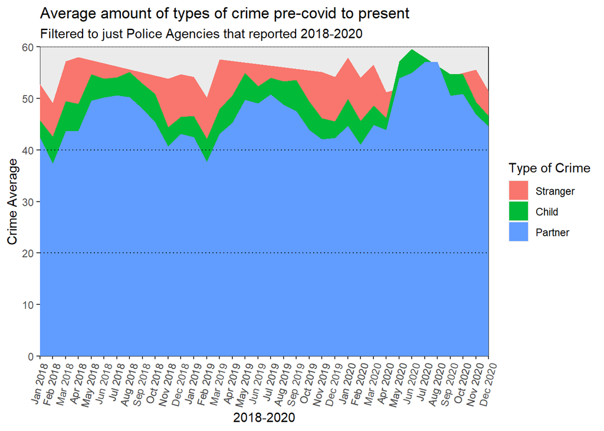

```r
# Mean
p1 = ggplot() +
  # theme_fivethirtyeight() +
  geom_area(data = fs, aes(x = year_month, y = stranger_crime_mean, fill = "black")) +
  geom_area(data = fs, aes(x = year_month, y = child_crime_mean, fill = "blue")) +
  geom_area(data = fs, aes(x = year_month, y = partner_crime_mean, fill = "red")) +   scale_x_yearmon(n = 47, expand = c(0, 0)) +
  scale_y_continuous(limits = c(0,60), expand = c(0, 0)) +
  theme(axis.text.x = element_text(angle = 75, vjust = 1, hjust=1),
        legend.title = element_text(),
        legend.position = "right",
        legend.direction = "vertical",
        plot.background = element_rect(fill = "white"),
        panel.grid.major = element_blank(),
        panel.grid.minor = element_blank(),
        panel.background = element_rect(colour = "grey18")
        )+
  xlab("2018-2020")+
  ylab("Crime Average") +
  guides(fill=guide_legend(title="Type of Crime")) +
  scale_fill_discrete(name = "Dose", labels = c("Stranger","Child","Partner")) +
  labs(title = "Average amount of types of crime pre-covid to present",subtitle = "Filtered to just Police Agencies that reported 2018-2020") +
  geom_hline(yintercept = 20,linetype = 'dotted', col = 'black') +
  geom_hline(yintercept = 40,linetype = 'dotted', col = 'black') +
  geom_hline(yintercept = 60,linetype = 'dotted', col = 'black')
p1
```

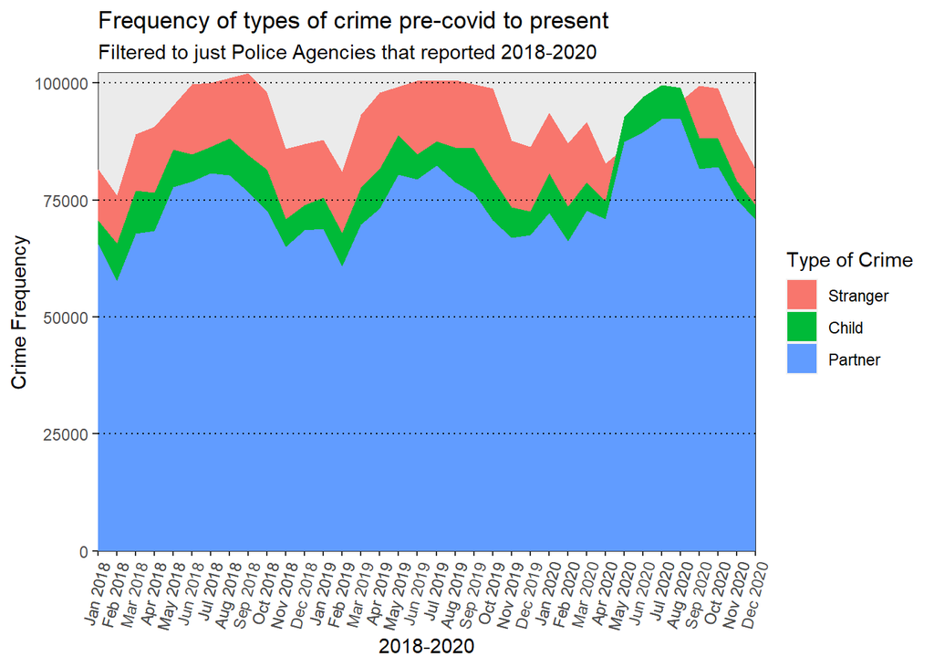

```r
# Sum
p2 = ggplot() +
  geom_area(data = fs, aes(x = year_month, y = stranger_crime, fill = "black")) +
  geom_area(data = fs, aes(x = year_month, y = child_crime, fill = "blue")) +
  geom_area(data = fs, aes(x = year_month, y = partner_crime, fill = "red")) +
  labs(title = "Frequency of types of crime pre-covid to present",subtitle = "Filtered to just Police Agencies that reported 2018-2020", x = "2018-2020", y = "Crime Frequency")+
  scale_x_yearmon(n = 47, expand = c(0, 0)) +
  scale_y_continuous(limits = c(0,102185), expand = c(0, 0)) +
  # theme_fivethirtyeight() +
  theme(axis.text.x = element_text(angle = 75, vjust = 1, hjust=1),
        legend.title = element_text(),
        legend.position = "right",
        legend.direction = "vertical",
        plot.background = element_rect(fill = "white"),
        panel.grid.major = element_blank(),
        panel.grid.minor = element_blank(),
        panel.background = element_rect(colour = "grey18")
)+
  xlab("2018-2020")+
  ylab("Crime Frequency") +
  guides(fill=guide_legend(title="Type of Crime")) +
  scale_fill_discrete(name = "Dose", labels = c("Stranger","Child","Partner")) +
  geom_hline(yintercept = 25000,linetype = 'dotted', col = 'black') +
  geom_hline(yintercept = 50000,linetype = 'dotted', col = 'black') +
  geom_hline(yintercept = 75000,linetype = 'dotted', col = 'black') +
  geom_hline(yintercept = 100000,linetype = 'dotted', col = 'black')
p2
```

Atp. at Density Plots. Doesn’t look that good.

```r
# # Sum Denisty
# p3 = ggplot() +
#   geom_area(data = fs, aes(x = year_month, y = child_crime), fill = "blue", alpha = 0.7) +
#   geom_area(data = fs, aes(x = year_month, y = partner_crime), fill = "blue",  alpha = 0.7) +
#   geom_area(data = fs, aes(x = year_month, y = stranger_crime), fill = "red", alpha = 0.7) +
#   scale_x_yearmon(n = 47) +
#   scale_y_continuous(limits = c(0,102185)) +
#   theme(axis.text.x = element_text(angle = 75, vjust = 1, hjust=1),
#         legend.title = element_text())+
#   xlab("Time")+
#   ylab("Crime Frequency") +
#   guides(fill=guide_legend(title="Type of Crime")) +
#   scale_fill_discrete(name = "Dose", labels = c("Child","Partner")) +
#   labs(title = "Frequency of types of crime pre-covid to present")
# p3
#
# p4 = ggplot() +
#   geom_area(data = fs, aes(x = year_month, y = stranger_crime), fill = "red", alpha = 0.9) +
#   geom_area(data = fs, aes(x = year_month, y = child_crime), fill = "blue", alpha = 0.9) +
#   # geom_area(data = fs, aes(x = year_month, y = partner_crime), fill = "blue",  alpha = 0.7) +
#   scale_x_yearmon(n = 47) +
#   scale_y_continuous(limits = c(0,102185)) +
#   theme(axis.text.x = element_text(angle = 75, vjust = 1, hjust=1),
#         legend.title = element_text())+
#   xlab("Time")+
#   ylab("Crime Frequency") +
#   guides(fill=guide_legend(title="Type of Crime")) +
#   scale_fill_discrete(name = "Dose", labels = c("Stranger","Child","Partner")) +
#   labs(title = "Frequency of types of crime pre-covid to present", subtitle = "Filtered to just Police Agencies that reported 2018-2019")
# p4
```

# for slides

$Crime_i = β_0 + β_1(Closure Estimator) + u_i$  
$Percent Crime_i = β_0 + β_1(Closure Estimator) + u_i$

$Crime_i= β_1(Closure Estimator) + β_2PopDens + β_3HHInc + β_4HH65 Percent + β_5Unemployment +$ $β_6Closure Estimator*HH65 Percent + β_7Population + FixedEffectMonth + u_i$

$Percent Crime_i = β_1(Closure Estimator) + β_2PopDens + β_3HHInc + β_4HH65 Percent + β_5Unemployment +$ $β_6Closure Estimator*HH65 Percent + β_7Population + FixedEffectMonth + u_i$

[output not shown]

“Stranger Crime” = feols( stranger_crime ~ pct_25pct_red + pop_dens + HH_inc + tfHH_65_percent + total_pop + clf_ue_percent + pct_25pct_red:tfHH_65_percent | month, data=df),

“Percent of Child Crime” = feols( percent_child ~ pct_25pct_red + pop_dens + HH_inc + tfHH_65_percent + clf_ue_percent + pct_25pct_red:tfHH_65_percent | month, data=df),

“Percent of Partner Crime” = feols( percent_partner ~ pct_25pct_red + pop_dens + HH_inc + tfHH_65_percent + clf_ue_percent + pct_25pct_red:tfHH_65_percent | month, data=df),